# Présentation pour la journée de l’enseignement

Engels Guyliann & Grosjean philippe

2019-03-22

## Introduction

Les étudiants du cours de Science des Données I de l’année académique 2018-2019 ont été les premiers étudiants à entrer dans la nouvelle philosophie proposée de cette suite de cours allant de SDD1 à SDD5. Ces cours axés sur la pratique sont donnés sous la forme de classe inversée. Parmi l’ensemble des outils mis à la dispotion des étudiants des séances d’exercice sous la forme de quiz interactif avec le package [learnr](https://rstudio.github.io/learnr/) ont été proposé. L’ensemble des résultats proposés par les étudiants durant ces quiz ont été sauvegardé dans une base de données dont ce document propose une première ébauche.

## La base de donénes

La base de données lié au cours de sdd1 comprend 45721 entrées. Ce cours fut composé de 20 quiz dont deux sont ceux lié aux examens. Nous retrouvons principalement deux types de questions au sein de ces quiz:

- Les zones de codes R

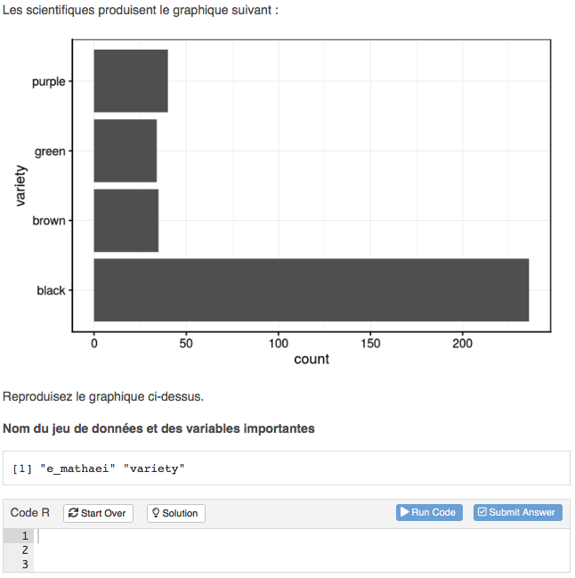

Pour valider cette exercice, il faut reproduire le graphique ci-dessus à l’aide des variables données `e_mathaei` et `variety` (les variables proposée sont expliqué précédement dans la séance d’exercice). Nous pouvons observer une zone de code avec différents boutons cliquables que sont :

- `Start Over` cette onglet propose de recommencer l’exercice,
- `Solution` cette onglet propose des indices et ou la réponse à l’exercice pour les étudiants n’y arrivant pas ou souhaitant vérifier leur réponse,
- `Run Code` cette onglet propose d’exécuter le code le nombre de fois qu’on le souhaite
- `Submit Answer`cette onglet propose de soumettre la réponse
- Les quiz

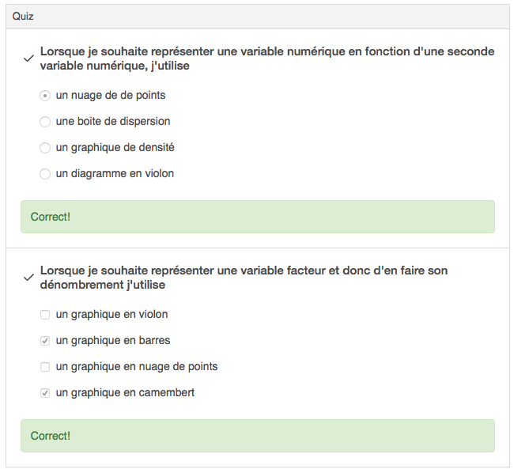

Pour valide cette exercice, il faut sélectionner les bonnes réponses à la question.

## Effort des étudiants

Il est très énergivore de concevoir des exerices en lignes proposant de s’exercer avec des lignes de codes. Il est dès lors intéressant de s’intéresser à la participation des étudiants pour chaque learnr. De plus, Le graphique suivant représente la densité des entrées dans la base de données en fonction de la séance d’exercice (nous parlerons dans ce cas des tutoriels par la suite) au cours du temps. Ce cours s’est déroulé durant le premier quadrimestre. Il a débuté début octobre et s’est terminé en janvier par un examen sous la forme d’un quiz intéractif du même type que ceux proposé durant le cours.

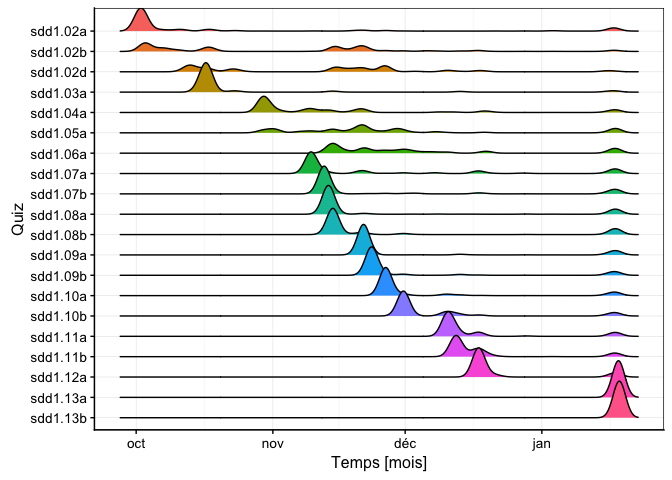

La majorité des tutoriels montre un pic assez concentrée avec un second pic plus léger la veille de l’examen. Les séances d’exercice dont les entrées sont moins concentrée peuvent être un premier indicateur de difficultés dans la réalisation des exercices. Attardons nous par exemple, sur la séance d’exercice **sdd1.04a**. Cette séance ne présente pas un beau pic comme le tutoriels **sdd1.03a** par exemple.

## **sdd1.04**

Cette séance d’exercice comprend 17 questions dont les 10 premières sont des réalisations d’exercices dans R suivi de 6 questions sous la forme de quiz et enfin une dernière entrée pour y indiquer un commentaire sur la séance d’exercice. Ce tutoriels représente 4007 entrée dans la base de données. Le graphique en barre suivant représente le nombre d’entrée (l’occurence) en fonction des questions du tutoriel. La première barre regroupe toutes les fois où les étudiants ont cliqué sur le bouton `Solution` et qu’ils sont passé d’une section à une autre de ce tutoriels. Les couleurs employés sur ce graphique représentent les événements. Quatre événement sont dénombré :.

- exercice_hint : L’étudiant a souhaité voir la réponse à la question d’une zone de code R
- exercise_submission : l’étudiant formule une réponse dans une zone de code R
- question_submission : l’étudiant formule une réponse à dans un quiz
- section_skipped: l’étudiant change de section dans la séance d’exercice

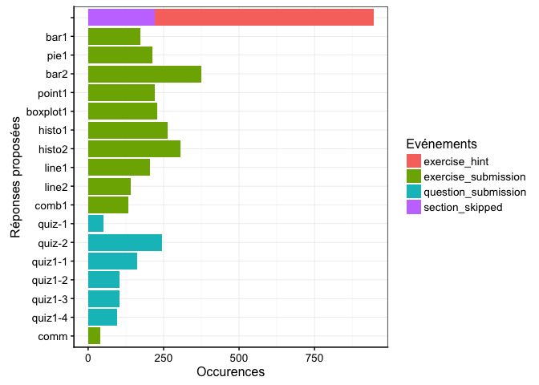

Tentons d’associer les événements `exercice_hint` à l’exercice correspondant. Nous partons du principe qu’avant de soumettre sa réponse l’étudiant va vérifier cette dernière en utilisant le bouton `solution`. Notre technique d’atribution n’est pas parfaite comme le montre le graphique A ci-dessus. Pour s’assurer de ne pas mal assigner les événement, nous décidons de retirer les appels à la solution (`exercise_hint`).

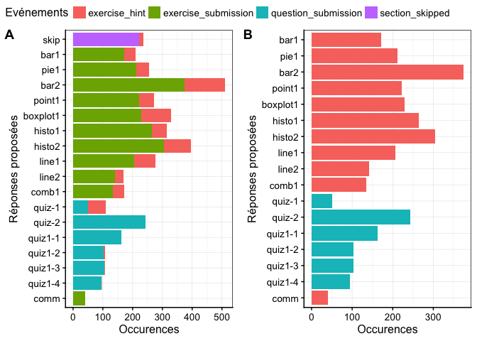

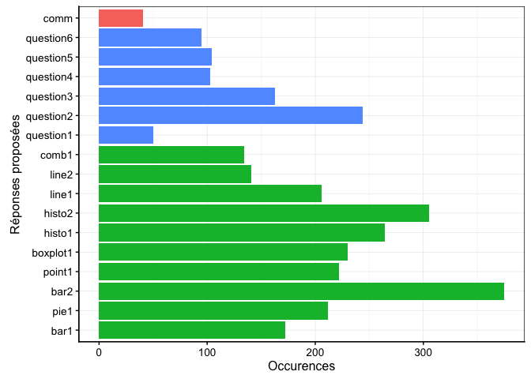

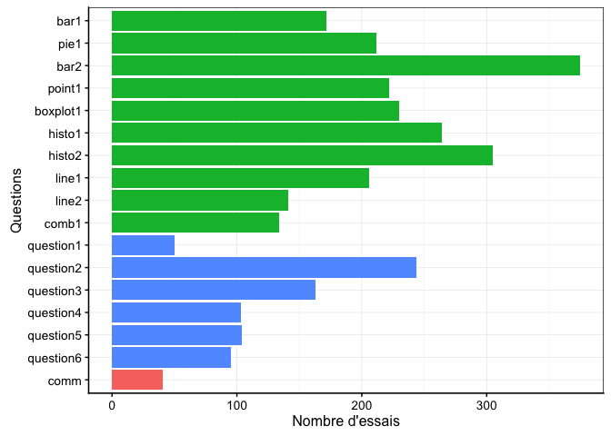

Au sein des différents exercices proposés durant ce tutoriels, nous décidons de porter notre attention sur 4 exercices dont :

- bar1
- bar2
- quiz1-2
- quiz2

### Zone de Code : comparaison entre l’exercice bar 1 et bar 2

Nous considérons qu’au dela de 20 minutes, l’étudiant ne tente pas activement de répondre à la question. La tableau suivant nous montre le nombre d’étudiants ayant validé la question sur les 38 étudiants ayant participé au quiz sdd1_04a.

[output not shown]

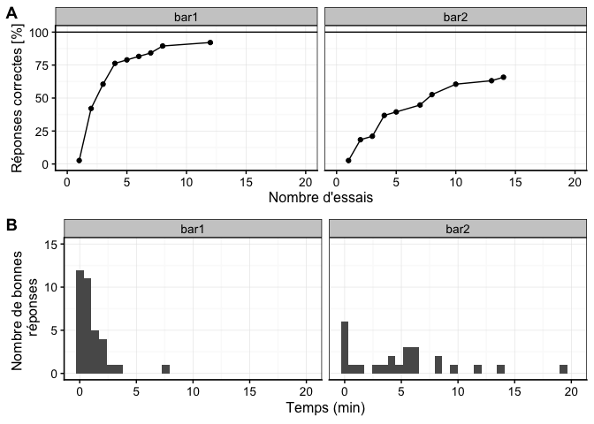

La question intitulée bar1 est validée par plus de 75% des étudiants après seulement 5 tentatives alors que la question bar2 n’attend jamais les 75% et ce même après 14 tentatives. Du point de vu de temps, entre la première tentative et la validation de l’exercice, nous observons un histogramme avec des classes bien resserées pour l’exercice 1 ce qui n’est pas le cas pour le quiz bar2. Sur base de deux descripteurs simples que sont le nombre de tentatives et le temps pour valider un exercice, nous pouvons mettre en avant une difficulté.

### Quiz

La même logique que pour la comparaison précédante est réalisée.

Le tableau ci-dessous met en avant les nombres d’étudiants ayant réponu aux questionx en moins de 20 (seuil que l’on a fixé comme limite pour répondre à une question) minutes par rapport aux 38

| Label de la question | Nombre d’étudiant |
| --- | --- |
| quiz-2 | 32 |
| quiz1-2 | 36 |

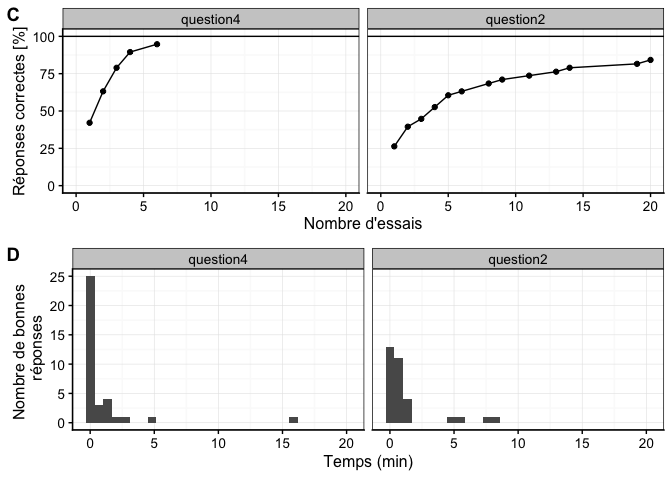

La question quiz-2 semble avoir été plus compliquée pour les étudiants. après 20 tentatives, plus de 80% des étudiants ont trouvé la bonne réponse alors qu’en seulement 6 tentatives 95 % des étudiants ont trouvé la bonne réponse à la question quiz1-2.

## Conclusion

La base de données couplées aux séances d’exercices permet de mettre en lumière les difficultés des étudiants. Le nombre de tentative et le temps nécessaire pour réaliser l’exerice sont de formidables outils afin d’améliorer les ressources proposées aux étudiants.